# Ch 13 Excercises

# Chapter 13 Excercises

## 1

**express the following second-order ODE as a first order system**
$$\frac{d^2}{dt^2}y -2\frac{d}{dt}y = \frac{1}{2}y^2 + f(t)$$

From the start of the chapter, lets set $\theta = \frac{dy}{dt}$ thus, we have

$$\frac{d}{dt}\theta y -2\theta y = \frac{1}{2}y^2 + f(t)$$
$$\frac{dy}{dt} = \theta$$

## 2

**Solve the following systems of ODEs: For t going form 0 to 100 in setps of size 0.005, and initial conidtions x = y = z = 1**
$$\frac{dx}{dt} = -\frac{8}{3}x + yz$$
$$\frac{dy}{dt} = -10(y-z)$$
$$\frac{dz}{dt} = -xy + 28y - z$$

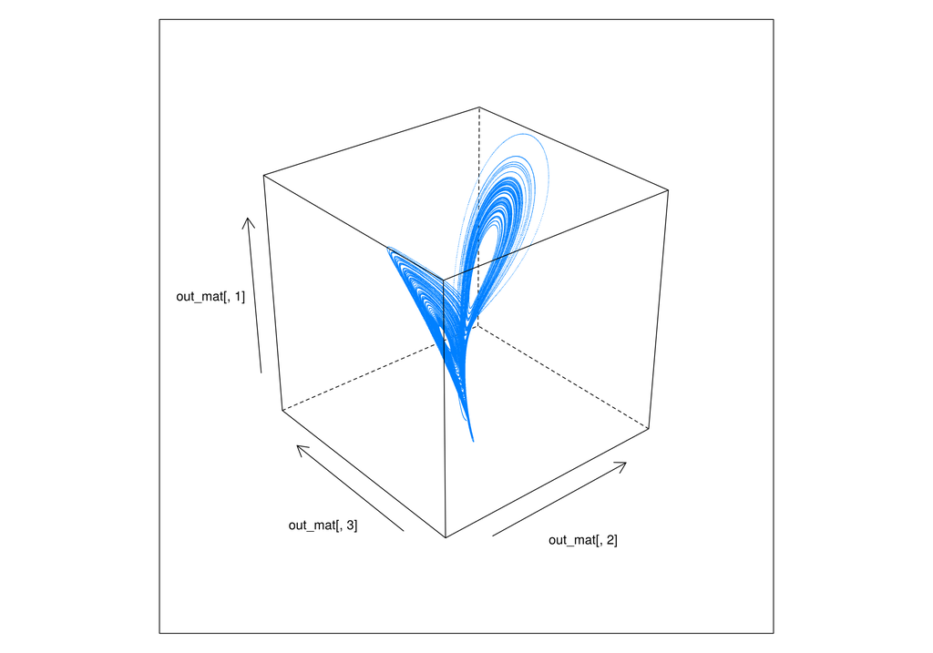

```r
Q2 = function(t= NULL, y){
  c(-8/3*y[1]+y[2]*y[3], -10*(y[2]-y[3]),-y[1]*y[2]+28*y[2]-y[3])
}

RK4adapt <- function(dydt, t0, y0, t1, h0 = 1, tol = 1e-10, ...) {
  # 4-th order Runge-Kutta with adaptive step size
  # dydt(t, y, ...) gives the gradient of y(t)
  # t0 and y0 are starting conditions
  # The system is solved up to time t1. Initial step size is h0,
  # which is adjusted so that the error in each step is approx tol.
  # Returns a list with elements t a vector giving times,
  # and y a matrix whose rows give the soltn at successive times.
  t <- t0  # current time
  y <- y0  # current state
  h <- h0  # current step size
  t.vec <- t
  y.vec <- matrix(y, nrow=1)
  while (t < t1) {
    # RK4 using step size h
    k1 <- dydt(t, y, ...)
    k2 <- dydt(t + h/2, y + h*k1/2, ...)
    k3 <- dydt(t + h/2, y + h*k2/2, ...)
    k4 <- dydt(t + h, y + h*k3, ...)
    y1 <- y + h*(k1/6 + k2/3 + k3/3 + k4/6)
    # RK4 using two steps size h/2
    k1a <- k1
    k2a <- dydt(t + h/4, y + h/2*k1a/2, ...)
    k3a <- dydt(t + h/4, y + h/2*k2a/2, ...)
    k4a <- dydt(t + h/2, y + h/2*k3a, ...)
    y2 <- y + h/2*(k1a/6 + k2a/3 + k3a/3 + k4a/6)
    k1b <- dydt(t + h/2, y2, ...)
    k2b <- dydt(t + 3*h/4, y2 + h/2*k1b/2, ...)
    k3b <- dydt(t + 3*h/4, y2 + h/2*k2b/2, ...)
    k4b <- dydt(t + h, y2 + h/2*k3b, ...)
    y3 <- y2 + h/2*(k1b/6 + k2b/3 + k3b/3 + k4b/6)
    # update h (decrease)
    if (max(abs(y3 - y1)) > tol) {
      h <- h/2
    } else {
      # update t and y
      t <- t + h
      y <- y3 + (y3 - y1)/15
      # update h (increase)
      if (max(abs(y3 - y1)) < tol/2) h <- 3*h/2
      # record keeping
      t.vec <- c(t.vec, t)
      y.vec <- rbind(y.vec, y)
    }
  }
  return(list(t=t.vec, y=y.vec))
}

out_RK4 = RK4adapt(Q2, 0, c(1,1,1), 100, h = 0.005)

out_mat = matrix(out_RK4[[2]], ncol = 3)
lattice::cloud(out_mat[,1] ~ out_mat[,2]*out_mat[,3], pch = ".")
```

## 3

**Taking a step size of h = 1, show that using the RK4 method to integrate f from 0 to 1 is equivalent to using Simpson’s method with a partition of size 2 (Ch. 11.2)**

from 11.2, we have Simpson’s rule:
$$S = \frac{h}{3}(f(x_0) + 4f(x_1)+2f(x_2)+4f(f_3)+...+4f(x_{n-1}) + f(x_n))$$

but becuase we are making 2 parititons w have X = {x0, x1, x2} and h = 1

$$S = \frac{1}{3}(f(x_0) + 4f(x_1)+ f(x_2)) = \frac{1}{3}(f(x_0) + 2f(x_1)+ 2f(x_1) + f(x_2))$$

$$= \frac{1}{3}*6 (\frac{f(x_0)}{6} + \frac{f(x_1)}{3}+ \frac{f(x_1)}{3} + \frac{f(x_2)}{6})$$
eh….relationally close enough!

## 5

**The SIR model for the spread of an epidemic is deinfed as follows:**  
**let S(t), I(t), R(t) by the number of Susceptible, Infected, adn Recovered individuals at time t. We treat these as continuous quantities, even though they are necessarily discrete in practice. SUppose that each Infected indicidual beomces Recovered at Rate** $\beta$ **, and each Infected individual infect each Susceptible at rate** $\alpha$ **, then we have:**

$$S'(t) = -\alpha I(t)S(t)$$
$$I'(t) = \alpha I(t)S(t) - \beta I(t)$$
$$R'(t) = \beta I(t)$$

**By looking at the I’(0), give a conidtion for the epidemic to die out quickly, in terms of** $\alpha \ ,\beta$**, and S(0). Test your condition by solving the system of the equations numerically, for a wide variety of initial conditions.**

Looking at it, Beta amd alpha have to be pretty high, let’s test that out, out!

```r
library(tidyverse)
```

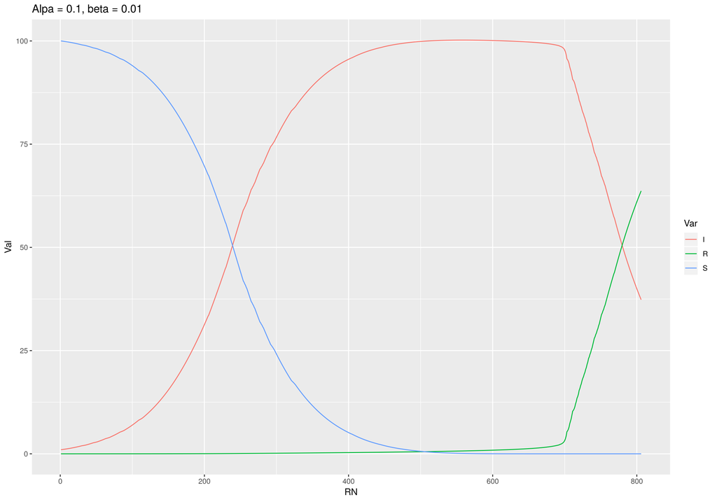

```r
Q3 = function(t = NULL, y, alpha, beta){
  c( alpha * y[1] * y[2] - beta * y[1], -1 * alpha * y[1]*y[2], beta*y[1])
}

#I, S, R

out_RK4 = RK4adapt(Q3, 0, c(1,100,0), 100, h = 0.05, alpha = 0.1, beta = 0.01)

data.frame(as.matrix(out_RK4[[2]], col =3)) %>%
  mutate(RN = row_number()) %>%
  rename(I = X1,
        S = X2,
        R = X3) %>%
  gather(Var, Val, 1:3) %>%
  ggplot(aes(x = RN, y = Val, col = Var)) +
    geom_line() +
    ggtitle('Alpa = 0.1, beta = 0.01')
```

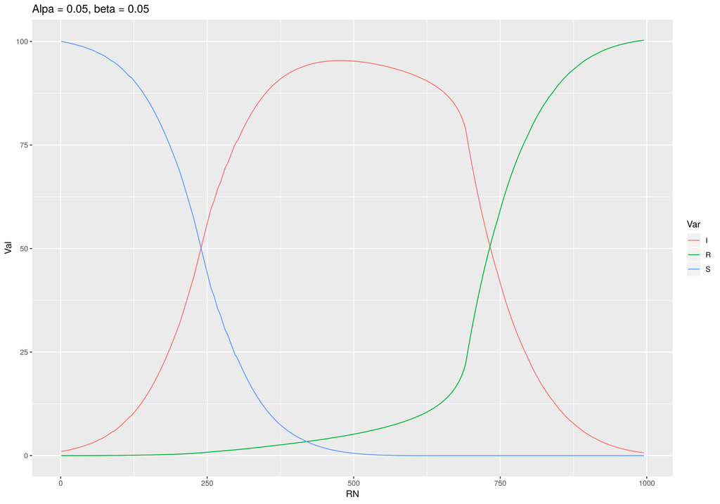

```r
out_RK4 = RK4adapt(Q3, 0, c(1,100,0), 100, h = 0.05, alpha = 0.05, beta = 0.05)

data.frame(as.matrix(out_RK4[[2]], col =3)) %>%
  mutate(RN = row_number()) %>%
  rename(I = X1,
        S = X2,
        R = X3) %>%
  gather(Var, Val, 1:3) %>%
  ggplot(aes(x = RN, y = Val, col = Var)) +
    geom_line() +
    ggtitle('Alpa = 0.05, beta = 0.05')
```

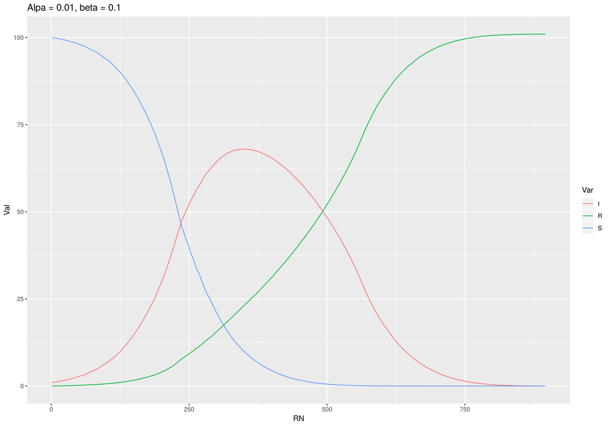

```r
out_RK4 = RK4adapt(Q3, 0, c(1,100,0), 100, h = 0.05, alpha = 0.01, beta = 0.1)

data.frame(as.matrix(out_RK4[[2]], col =3)) %>%
  mutate(RN = row_number()) %>%
  rename(I = X1,
        S = X2,
        R = X3) %>%
  gather(Var, Val, 1:3) %>%
  ggplot(aes(x = RN, y = Val, col = Var)) +
    geom_line() +
    ggtitle('Alpa = 0.01, beta = 0.1')
```